# Report

Xijia Luo

December 14, 2020

# Introduction

This project is about text mining which we have learnt in the second half of the semester. Since most of us will be looking for a job after graduation next semester, doing some text exploration and mining work about data science or statistical job description will be very helpful for us in the future. We crawled data from Indeed which is an American worldwide employment website for job listings launched.

indeed link: https://www.indeed.com/

[figure not shown]

We use all kinds of text mining and R knowledge we learned in class to process and analyze the original data to study the following questions.

1. Which skills and knowledge we need to master
2. What are we going to do in the job?
3. Requirements for years of working experience?

# Data crawling

The first thing we need to do is to crawl the data from the target site. The procedures and detailed codes can be found in the indee_scrape.R file under the same repository directory from my github. Here is a preview of data I got.

| title | company | location | summary |
| --- | --- | --- | --- |
| Junior Data Scientist | World Bank Group | Washington, DC | We are looking for an environmental analyst with strong data science skills to help us strengthen the methodology, data and the data management systems behind… |
| Early career data scientist / analyst / statistical genetici... | Data Tecnica | Glen Echo, MD | This will focus on running and refining standard analysis, data management and data visualization workflows. |
| Data Scientist Intern | McGraw Hill | NA | Experience with standard data science packages and methodologies. |
| Associate Data Scientist - PLMI Analytics | Cleveland Clinic | Cleveland, OH | Certification or fellowship in analytics, big data, data science or related subject preferred. |
| HUMAN RESOURCES SPECIALIST (RECRUITMENT & CLASSIFICATION) | US Department of the Navy | Mechanicsburg, PA | Certain current or former term or temporary federal employees of a land or base management agency. |

I didn't display the decription part for it is too long which not fit the page well. Also, if you want see the complete dataset, you would find it the listings.csv file under the same repository directory from my github.

# Location distribution

The location of a job is an important indicator to judge personal fit. In this part, I will do some EDA work for my original dataset show the distribution of the jobs provided on the indeed.com. The data crawled by everyone is very different, because it will change according to your IP address. Therefore, I strongly recommend that you run the data crawler R file provided by me before using my report and shinyapp, so that my analysis report and shinyapp can be more helpful since the more jobs in the dataset are near your location.

| title | company | city | state |
| --- | --- | --- | --- |
| Junior Data Scientist | World Bank Group | Washington | DC |
| Early career data scientist / analyst / statistical genetici... | Data Tecnica | Glen Echo | MD |
| Data Scientist Intern | McGraw Hill | Whole Country | Whole Country |
| Associate Data Scientist - PLMI Analytics | Cleveland Clinic | Cleveland | OH |
| HUMAN RESOURCES SPECIALIST (RECRUITMENT & CLASSIFICATION) | US Department of the Navy | Mechanicsburg | PA |

Firstly, I separate the column "Location" into variable "City" and "State". Then, I reassign all Na value as "whole country" because many jobs do not specify specific locations so that it is responsible to consider them as nationwide.

| state | count |
| --- | --- |
| PA | 31 |
| Whole Country | 29 |
| NY | 17 |
| MD | 11 |
| CA | 10 |

I sorted out the number of data scientist and statistics related jobs in each state and ranked them in descending order. The top state is Pennsylvania main because I am in State college, PA right now. Second in the list is the country, which is also very persuasive since Under the influence of covid19, many companies, especially technology companies, allow employees to work from home. Thus, it is reasonable not to provide location information when recruiting. The economy of NY and Ca is very developed, and there are many financial technology companies. So their demand for talent in data science will be higher than in other states.

| state | city | count |
| --- | --- | --- |
| NY | New York | 14 |
| PA | Harrisburg | 12 |
| DC | Washington | 6 |
| IL | Chicago | 5 |
| GA | Atlanta | 4 |

Then we move on to the cities. From the result, we can find out that the more prosperous and developed a big city is, the more job opportunities there are. For example, New York as the top1 city in the world, has the most data science and statistical related job opportunities. As a conclusion, there are more demand for employee who mastered data science in economically developed areas.

# Common Word Analyze

In this part, I will do some text mining work for the column "description" to see what's are the most common words a company will use when recruiting online. I also doing some data visualization work to display the word frequency more dynamic by making a word cloud.

### Table

| word | n |
| --- | --- |
| data | 1489 |
| experience | 585 |
| science | 388 |
| business | 344 |
| team | 290 |
| skills | 278 |
| learning | 262 |
| analysis | 235 |
| ability | 231 |
| analytics | 208 |
| information | 197 |
| machine | 193 |
| required | 191 |
| position | 188 |
| time | 183 |

### Rank

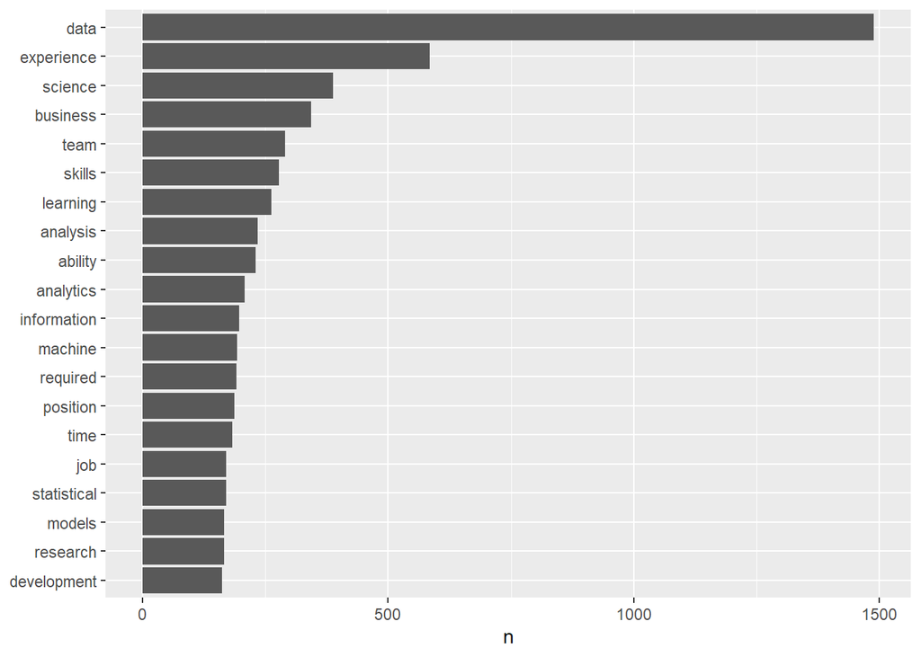

### Word Cloud

[interactive chart not shown]

From the result, we can make a summary of the work content and requirements. The content of the work includes working in "team" dealing with various "data", mastering various "skills", "ability" and working "experience". The main "business" is to "analysis" "information".The necessay "required" skills include "modeling", "python", "research", and "computer".

# Common Phrase Analyze

When I was writing the analysis in last part, I feel constrained. For example, "machine" and "engineering" are both very high frequency words, however we are looking for a job about data science not mechanical engineering. Therefore, I think the lerning phrase is very important.Here I mainly study two word phrases, and then do some data visualization.

### Phrase Table

| word1 | word2 | n |
| --- | --- | --- |
| data | science | 243 |
| machine | learning | 183 |
| data | scientist | 125 |
| computer | science | 73 |
| equal | opportunity | 60 |
| communication | skills | 55 |
| data | analysis | 55 |
| sexual | orientation | 51 |
| national | origin | 46 |
| gender | identity | 45 |
| data | mining | 43 |
| data | visualization | 43 |
| opportunity | employer | 42 |
| veteran | status | 41 |
| data | sources | 40 |

### Phrase Rank

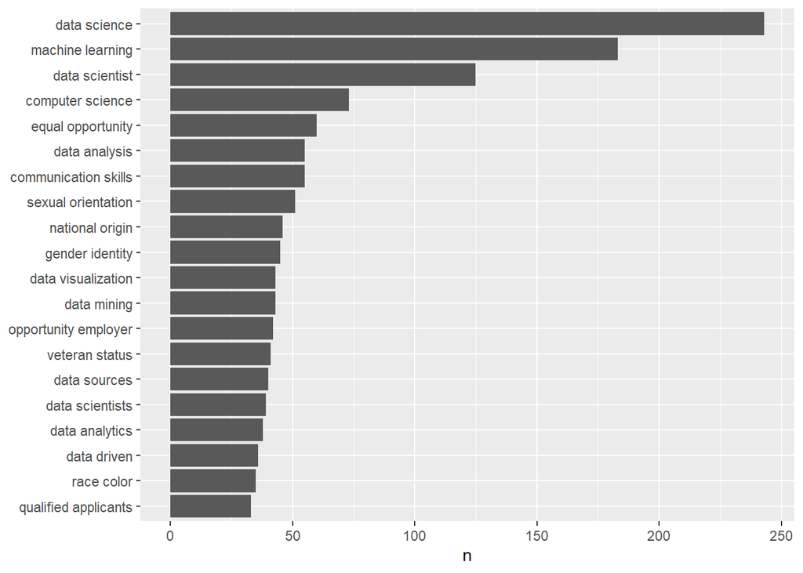

### Phrase Cloud

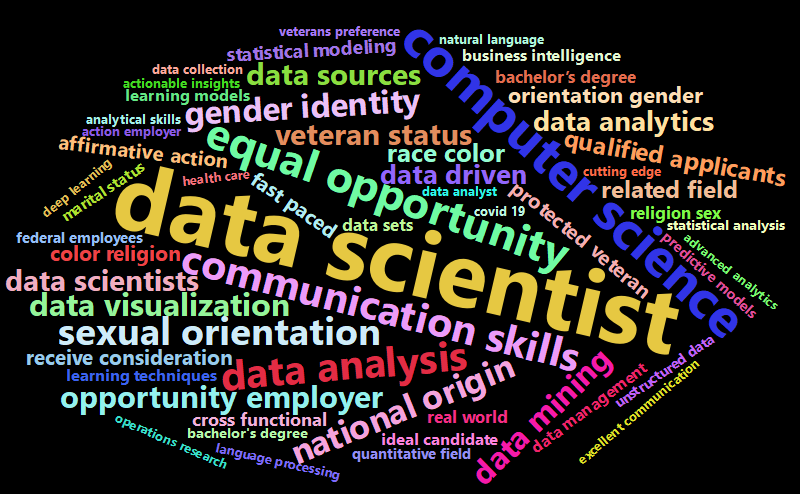

### Phrase Nod Network

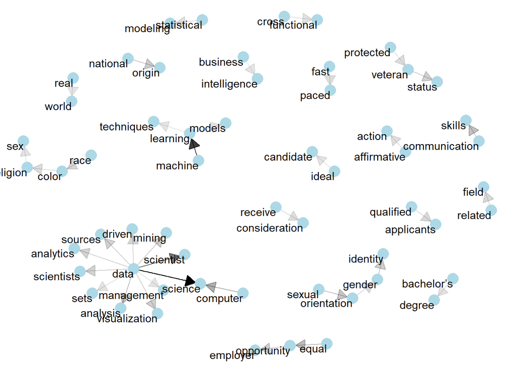

### Search Box

Besides word data, there are plent of other interesting words and related phrase depend on users. Thus, I made a search box in my shiny app to let user search the key words they are interested in. The output will be a rank of frequency about the key word you input and its related phrase. If you want use this function, you may run the Report.Rmd again by yourself under the same repository directory from my github.

For example, when we doing the words frequency check, we find out that work experience important. Then we can search years in the search box above to see most common Work experience requirement for data science jobs. Here is the result.

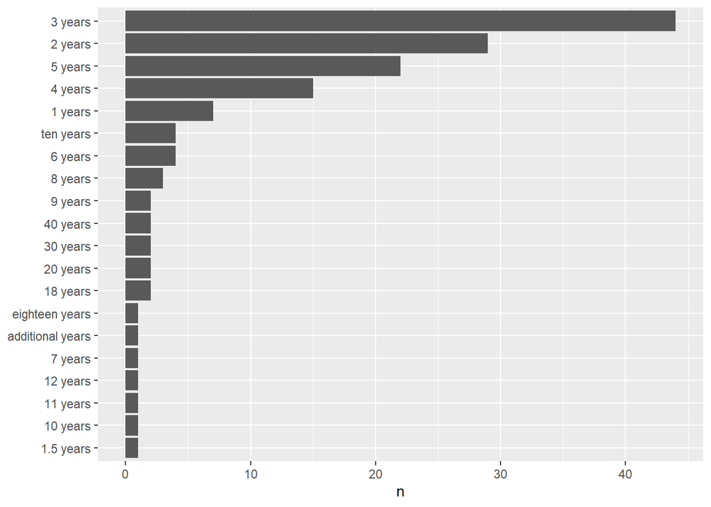

From the plot we can see that most jobs required a employee with at least 2 years of working experience and the most common requirement is 3 years.

# Conclusion

We found some advantages and disadvantages of looking for a data science and statistical job through this project. The advantage is that we all have strong teamwork and communication skills. This is due to the fact that we have been working as a team during the graduate study at BU MSSP. Another advantage is that our expertise is well matched. Including the text mining I used this time, the modeling skills I learned in class 678, and the machine learning I will learn in class 679 next semester. Our disadvantage is that we don't have enough work experience. Most of our jobs require two years of working experience.